# Tools Comparison (Detailed): OpenCode + Opus 4.6

## Run Metadata

- Harness: `opencode`
- Model: `opus-4-6`
- Prompt type: `detailed`

## Setup

```r
library(MASS)
library(dplyr)       # loaded after MASS so dplyr::select() is not masked
library(ggplot2)
library(tidyr)
library(broom)
library(scales)
library(patchwork)
library(knitr)
library(kableExtra)

df <- readr::read_csv(here::here("data/synthetic/simulated_maternal_health_data.csv"))
```

## Prompt

```
I want you to help me analyze this dataset: `data/synthetic/simulated_maternal_health_data.csv`

My goal is to produce a thorough analysis that is statistically sound and lays out all steps of the analysis.

Please do the following:

1. Load the dataset and normalize columns/types.
   - Use clear snake_case names.
   - Ensure categorical vs numeric types are explicit.

2. Summarize the data.
   - Report row count, column count, missingness, and key descriptive summaries.
   - Flag suspicious values or quality concerns.

3. Create key visualizations.
   - Show relationships for:
     - `received_comprehensive_postnatal_care`
     - `distance_to_provider`
     - `insurance`
     - `race_ethnicity`

4. Build a count outcome and model it.
   - Define `comorbidity_count` as the row-wise sum of:
     - `obesity`,
     - `multiple_gestation`,
     - `diabetes`,
     - `heart_disease`,
     - `placenta_previa`,
     - `hypertension`,
     - `gest_hypertension`,
     - `preeclampsia`.
   - Select an appropriate count-model strategy (Poisson vs negative binomial, with justification).
   - Fit the model and report interpretable results.

5. Report results responsibly.
   - Do not overstate causality.
   - Include model assumptions, diagnostics, and limitations.

Constraints:
- Prefer readable, modular, reproducible code that follows R community idioms.
- Report back a summary of what you changed.
```

## Analysis

### 1. Load and Normalize Data

Column names are already in `snake_case`. We convert categorical variables to explicit factors with meaningful level ordering and recode the income variable to an ordered factor.

```r
# Define ordered income levels
income_levels <- c(
  "$0–$24,999",
  "$25,000–$49,999",
  "$50,000–$74,999",
  "$75,000–$99,999",
  "$100,000–$124,999",
  "$125,000–$149,999",
  "$150,000–$174,999",
  "$175,000+"
)

# Define ordered education levels
edu_levels <- c("less_than_hs", "hs", "some_college", "college", "post_grad")
edu_labels <- c("Less than HS", "High School", "Some College", "College", "Post-Grad")

df <- df |>
  mutate(
    # Binary outcome as factor
    received_comprehensive_postnatal_care = factor(
      received_comprehensive_postnatal_care,
      levels = c(0, 1),
      labels = c("No", "Yes")
    ),

    # Ordered factors
    self_report_income = factor(self_report_income, levels = income_levels, ordered = TRUE),
    edu = factor(edu, levels = edu_levels, labels = edu_labels, ordered = TRUE),

    # Unordered categorical
    race_ethnicity = factor(race_ethnicity),
    insurance = factor(insurance, levels = c("no_insurance", "state_provided", "private")),
    job_type = factor(job_type),
    state = factor(state),
    provider_id = factor(provider_id),

    # Binary indicators remain numeric (0/1) for modeling
    across(
      c(obesity, multiple_gestation, diabetes, heart_disease,
        placenta_previa, hypertension, gest_hypertension, preeclampsia),
      as.integer
    )
  )
```

### 2. Data Summary

#### Dimensions and Missingness

```r
tibble(
  Metric = c("Rows", "Columns", "Total cells", "Total missing values"),
  Value = c(
    format(nrow(df), big.mark = ","),
    ncol(df),
    format(nrow(df) * ncol(df), big.mark = ","),
    sum(is.na(df))
  )
) |>
  kable(align = "lr") |>
  kable_styling(bootstrap_options = "striped", full_width = FALSE)
```

| Metric | Value |
| --- | --- |
| Rows | 50,000 |
| Columns | 20 |
| Total cells | 1,000,000 |
| Total missing values | 0 |

```r
missingness <- df |>
  summarise(across(everything(), ~ sum(is.na(.)))) |>
  pivot_longer(everything(), names_to = "column", values_to = "n_missing") |>
  mutate(pct_missing = n_missing / nrow(df) * 100) |>
  filter(n_missing > 0)

if (nrow(missingness) == 0) {
  cat("No missing values detected in any column.\n")
} else {
  missingness |>
    arrange(desc(n_missing)) |>
    kable(digits = 2) |>
    kable_styling(bootstrap_options = "striped", full_width = FALSE)
}
```

```
No missing values detected in any column.
```

#### Descriptive Statistics — Numeric Variables

```r
df |>
  select(age, dependents, distance_to_provider) |>
  pivot_longer(everything(), names_to = "variable", values_to = "value") |>
  group_by(variable) |>
  summarise(
    n = n(),
    mean = mean(value),
    sd = sd(value),
    min = min(value),
    q25 = quantile(value, 0.25),
    median = median(value),
    q75 = quantile(value, 0.75),
    max = max(value),
    .groups = "drop"
  ) |>
  kable(digits = 2) |>
  kable_styling(bootstrap_options = "striped", full_width = FALSE)
```

| variable | n | mean | sd | min | q25 | median | q75 | max |
| --- | --- | --- | --- | --- | --- | --- | --- | --- |
| age | 50000 | 28.02 | 6.26 | 15 | 23.0 | 28 | 32.00 | 44.00 |
| dependents | 50000 | 2.38 | 0.95 | 0 | 2.0 | 2 | 3.00 | 8.00 |
| distance_to_provider | 50000 | 14.52 | 14.59 | 0 | 4.1 | 10 | 20.24 | 163.42 |

#### Descriptive Statistics — Categorical Variables

```r
cat_vars <- c(
  "received_comprehensive_postnatal_care", "self_report_income",
  "edu", "race_ethnicity", "insurance", "job_type"
)

cat_summary <- df |>
  select(all_of(cat_vars)) |>
  mutate(across(everything(), as.character)) |>
  pivot_longer(everything(), names_to = "variable", values_to = "level") |>
  count(variable, level) |>
  group_by(variable) |>
  mutate(pct = n / sum(n) * 100) |>
  ungroup()

cat_summary |>
  kable(digits = 1, col.names = c("Variable", "Level", "N", "%")) |>
  kable_styling(bootstrap_options = "striped", full_width = FALSE) |>
  collapse_rows(columns = 1, valign = "top")
```

| Variable | Level | N | % |
| --- | --- | --- | --- |
| edu | College | 5269 | 10.5 |
|  | High School | 23108 | 46.2 |
|  | Less than HS | 5218 | 10.4 |
|  | Post-Grad | 1446 | 2.9 |
|  | Some College | 14959 | 29.9 |
| insurance | no_insurance | 20810 | 41.6 |
|  | private | 17908 | 35.8 |
|  | state_provided | 11282 | 22.6 |
| job_type | professional | 14293 | 28.6 |
|  | trade | 6298 | 12.6 |
|  | unemployed | 2217 | 4.4 |
|  | unskilled | 27192 | 54.4 |
| race_ethnicity | aian | 387 | 0.8 |
|  | asian | 3059 | 6.1 |
|  | black | 5878 | 11.8 |
|  | hispanic | 8792 | 17.6 |
|  | nhpi | 90 | 0.2 |
|  | other | 283 | 0.6 |
|  | white | 31511 | 63.0 |
| received_comprehensive_postnatal_care | No | 33851 | 67.7 |
|  | Yes | 16149 | 32.3 |
| self_report_income | $0–$24,999 | 607 | 1.2 |
|  | $100,000–$124,999 | 2720 | 5.4 |
|  | $125,000–$149,999 | 667 | 1.3 |
|  | $150,000–$174,999 | 171 | 0.3 |
|  | $175,000+ | 62 | 0.1 |
|  | $25,000–$49,999 | 14710 | 29.4 |
|  | $50,000–$74,999 | 21279 | 42.6 |
|  | $75,000–$99,999 | 9784 | 19.6 |

#### Comorbidity Prevalence

```r
comorbidity_vars <- c(
  "obesity", "multiple_gestation", "diabetes", "heart_disease",
  "placenta_previa", "hypertension", "gest_hypertension", "preeclampsia"
)

df |>
  select(all_of(comorbidity_vars)) |>
  pivot_longer(everything(), names_to = "condition", values_to = "present") |>
  group_by(condition) |>
  summarise(
    n_present = sum(present),
    prevalence_pct = mean(present) * 100,
    .groups = "drop"
  ) |>
  arrange(desc(prevalence_pct)) |>
  kable(digits = 1, col.names = c("Condition", "N Present", "Prevalence (%)")) |>
  kable_styling(bootstrap_options = "striped", full_width = FALSE)
```

| Condition | N Present | Prevalence (%) |
| --- | --- | --- |
| obesity | 17500 | 35 |
| hypertension | 10000 | 20 |
| heart_disease | 7500 | 15 |
| diabetes | 5000 | 10 |
| gest_hypertension | 2500 | 5 |
| multiple_gestation | 1500 | 3 |
| preeclampsia | 1000 | 2 |
| placenta_previa | 500 | 1 |

#### Data Quality Notes

```r
# Check age range
cat("Age range:", range(df$age), "\n")
```

```
Age range: 15 44
```

```r
# Check distance for extreme values
dist_q99 <- quantile(df$distance_to_provider, 0.99)
n_extreme_dist <- sum(df$distance_to_provider > 100)
cat("Distance 99th percentile:", round(dist_q99, 1), "miles\n")
```

```
Distance 99th percentile: 66.5 miles
```

```r
cat("Observations with distance > 100 miles:", n_extreme_dist,
    paste0("(", round(n_extreme_dist / nrow(df) * 100, 2), "%)"), "\n")
```

```
Observations with distance > 100 miles: 57 (0.11%)
```

```r
# Check dependents range
cat("Dependents range:", range(df$dependents), "\n")
```

```
Dependents range: 0 8
```

> **Quality assessment:** No missing data. Age range (15–44) is plausible for a maternal health dataset. Distance to provider is right-skewed with a small number of extreme values (> 100 miles), which is realistic for rural settings but should be monitored during modeling. All binary comorbidity indicators are coded 0/1 with no out-of-range values.

### 3. Key Visualizations

#### Postnatal Care by Insurance Status

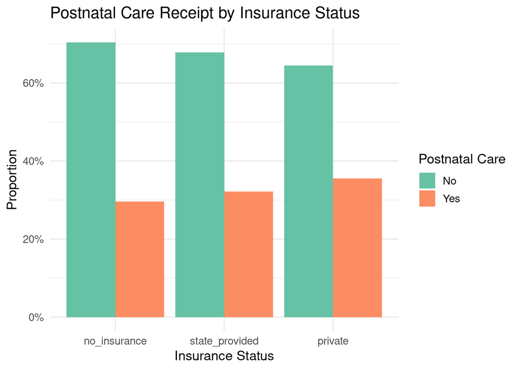

Figure 1: Receipt of comprehensive postnatal care by insurance status

```r
df |>
  count(insurance, received_comprehensive_postnatal_care) |>
  group_by(insurance) |>
  mutate(pct = n / sum(n)) |>
  ungroup() |>
  ggplot(aes(x = insurance, y = pct, fill = received_comprehensive_postnatal_care)) +
  geom_col(position = "dodge") +
  scale_y_continuous(labels = percent_format()) +
  scale_fill_brewer(palette = "Set2", name = "Postnatal Care") +
  labs(
    x = "Insurance Status",
    y = "Proportion",
    title = "Postnatal Care Receipt by Insurance Status"
  ) +
  theme_minimal(base_size = 13)
```

#### Postnatal Care by Race/Ethnicity

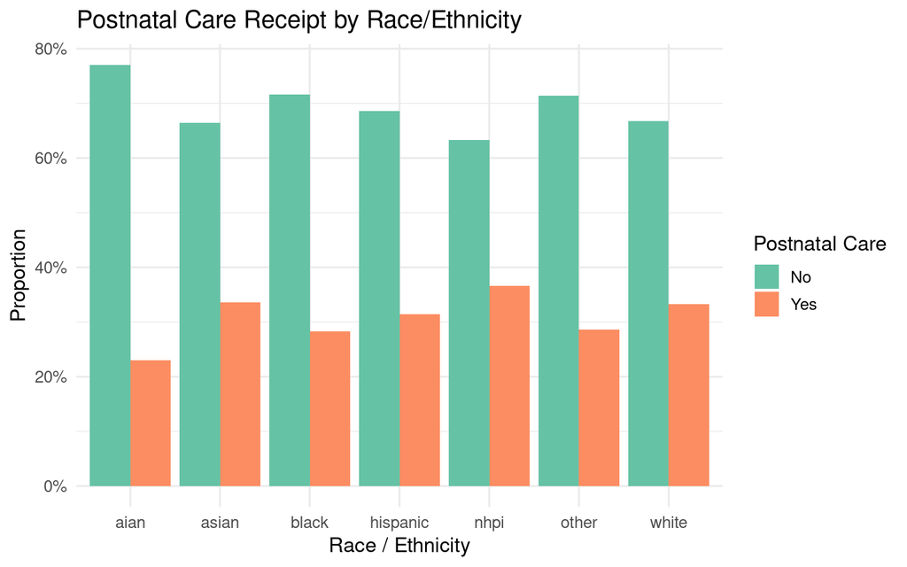

Figure 2: Receipt of comprehensive postnatal care by race/ethnicity

```r
df |>
  count(race_ethnicity, received_comprehensive_postnatal_care) |>
  group_by(race_ethnicity) |>
  mutate(pct = n / sum(n)) |>
  ungroup() |>
  ggplot(aes(x = reorder(race_ethnicity, -pct), y = pct,
             fill = received_comprehensive_postnatal_care)) +
  geom_col(position = "dodge") +
  scale_y_continuous(labels = percent_format()) +
  scale_fill_brewer(palette = "Set2", name = "Postnatal Care") +
  labs(
    x = "Race / Ethnicity",
    y = "Proportion",
    title = "Postnatal Care Receipt by Race/Ethnicity"
  ) +
  theme_minimal(base_size = 13)
```

#### Distance to Provider Distribution

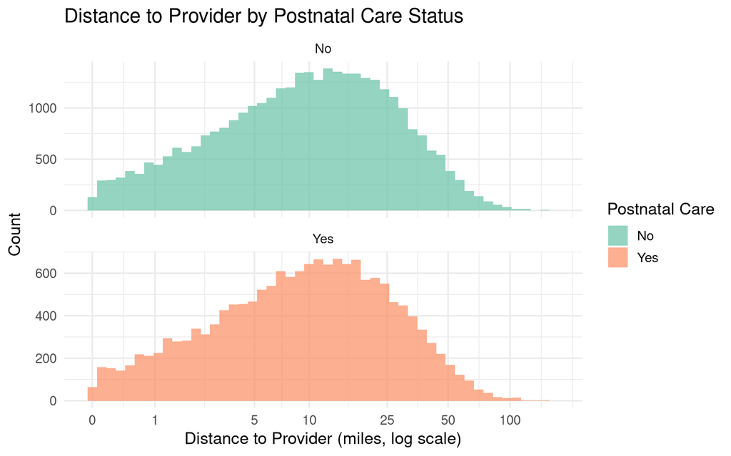

Figure 3: Distribution of distance to provider, faceted by postnatal care receipt

```r
ggplot(df, aes(x = distance_to_provider, fill = received_comprehensive_postnatal_care)) +
  geom_histogram(bins = 50, alpha = 0.7, position = "identity") +
  scale_x_continuous(trans = "log1p", breaks = c(0, 1, 5, 10, 25, 50, 100)) +
  scale_fill_brewer(palette = "Set2", name = "Postnatal Care") +
  facet_wrap(~ received_comprehensive_postnatal_care, ncol = 1, scales = "free_y") +
  labs(
    x = "Distance to Provider (miles, log scale)",
    y = "Count",
    title = "Distance to Provider by Postnatal Care Status"
  ) +
  theme_minimal(base_size = 13)
```

#### Distance to Provider by Insurance and Race

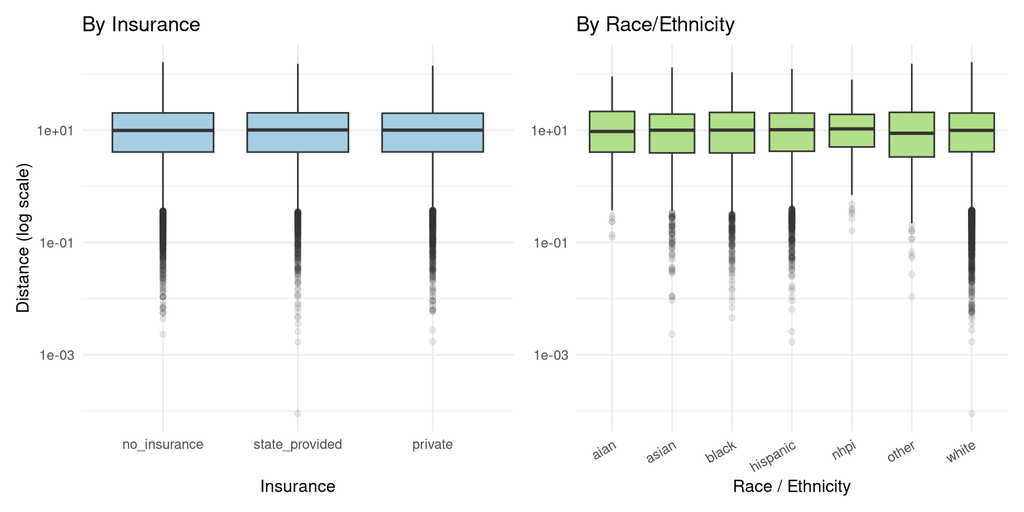

Figure 4: Distance to provider by insurance status and race/ethnicity

```r
p1 <- ggplot(df, aes(x = insurance, y = distance_to_provider)) +
  geom_boxplot(fill = "#a6cee3", outlier.alpha = 0.1) +
  scale_y_log10() +
  labs(x = "Insurance", y = "Distance (log scale)", title = "By Insurance") +
  theme_minimal(base_size = 12)

p2 <- ggplot(df, aes(x = race_ethnicity, y = distance_to_provider)) +
  geom_boxplot(fill = "#b2df8a", outlier.alpha = 0.1) +
  scale_y_log10() +
  labs(x = "Race / Ethnicity", y = NULL, title = "By Race/Ethnicity") +
  theme_minimal(base_size = 12) +
  theme(axis.text.x = element_text(angle = 30, hjust = 1))

p1 + p2
```

### 4. Count Model: Comorbidity Count

#### Construct the Outcome

```r
df <- df |>
  mutate(
    comorbidity_count = obesity + multiple_gestation + diabetes +
      heart_disease + placenta_previa + hypertension +
      gest_hypertension + preeclampsia
  )

cat("Comorbidity count distribution:\n")
```

```
Comorbidity count distribution:
```

```r
table(df$comorbidity_count) |> print()
```

```
    0     1     2     3     4     5     6     7
21350 16560  8359  2873   706   134    17     1
```

```r
cat("\nMean:", round(mean(df$comorbidity_count), 3),
    " Variance:", round(var(df$comorbidity_count), 3), "\n")
```

```
Mean: 0.91  Variance: 0.995
```

#### Model Selection: Poisson vs. Negative Binomial

For count data, Poisson regression assumes the mean equals the variance (equidispersion). If the variance exceeds the mean, overdispersion is present and a negative binomial model is more appropriate because it adds a dispersion parameter.

```r
mean_cc <- mean(df$comorbidity_count)
var_cc <- var(df$comorbidity_count)
cat("Mean:", round(mean_cc, 3), "\n")
```

```
Mean: 0.91
```

```r
cat("Variance:", round(var_cc, 3), "\n")
```

```
Variance: 0.995
```

```r
cat("Variance / Mean ratio:", round(var_cc / mean_cc, 3), "\n")
```

```
Variance / Mean ratio: 1.094
```

```r
fit_pois <- glm(
  comorbidity_count ~ age + self_report_income + edu + race_ethnicity +
    insurance + job_type + dependents + distance_to_provider +
    received_comprehensive_postnatal_care,
  data = df,
  family = poisson(link = "log")
)
```

```r
# Residual deviance / df as quick overdispersion check
deviance_ratio <- deviance(fit_pois) / df.residual(fit_pois)
cat("Residual deviance / df:", round(deviance_ratio, 3), "\n")
```

```
Residual deviance / df: 1.212
```

```r
cat("If substantially > 1, overdispersion is present.\n")
```

```
If substantially > 1, overdispersion is present.
```

```r
fit_nb <- glm.nb(
  comorbidity_count ~ age + self_report_income + edu + race_ethnicity +
    insurance + job_type + dependents + distance_to_provider +
    received_comprehensive_postnatal_care,
  data = df
)

cat("Negative binomial theta:", round(fit_nb$theta, 3), "\n")
```

```
Negative binomial theta: 10.232
```

```r
cat("(Smaller theta = more overdispersion; as theta -> Inf, NB -> Poisson)\n")
```

```
(Smaller theta = more overdispersion; as theta -> Inf, NB -> Poisson)
```

#### Model Comparison

```r
aic_comp <- tibble(
  Model = c("Poisson", "Negative Binomial"),
  AIC = c(AIC(fit_pois), AIC(fit_nb)),
  `Log-Likelihood` = c(logLik(fit_pois), logLik(fit_nb))
)

aic_comp |>
  kable(digits = 1) |>
  kable_styling(bootstrap_options = "striped", full_width = FALSE)
```

| Model | AIC | Log-Likelihood |
| --- | --- | --- |
| Poisson | 127022.3 | -63484.1 |
| Negative Binomial | 126854.0 | -63399.0 |

```r
# Likelihood ratio test: NB vs Poisson (NB nests Poisson when theta -> Inf)
lr_stat <- 2 * (logLik(fit_nb) - logLik(fit_pois))
lr_pval <- pchisq(as.numeric(lr_stat), df = 1, lower.tail = FALSE)
cat("LR test statistic:", round(as.numeric(lr_stat), 1), "\n")
```

```
LR test statistic: 170.3
```

```r
cat("p-value:", format.pval(lr_pval), "\n")
```

```
p-value: < 2.22e-16
```

> **Decision:** We select the negative binomial model based on (1) the variance-to-mean ratio exceeding 1, (2) lower AIC, and (3) a significant likelihood ratio test rejecting the Poisson constraint.

#### Negative Binomial Results

```r
summary(fit_nb)
```

```
Call:
glm.nb(formula = comorbidity_count ~ age + self_report_income +
    edu + race_ethnicity + insurance + job_type + dependents +
    distance_to_provider + received_comprehensive_postnatal_care,
    data = df, init.theta = 10.23214401, link = log)

Coefficients:
                                           Estimate Std. Error z value Pr(>|z|)
(Intercept)                              -0.6244657  0.0663796  -9.407  < 2e-16
age                                       0.0164114  0.0008270  19.844  < 2e-16
self_report_income.L                     -0.1960913  0.0913843  -2.146 0.031890
self_report_income.Q                     -0.0608792  0.0848899  -0.717 0.473279
self_report_income.C                     -0.0138666  0.0749013  -0.185 0.853126
self_report_income^4                      0.0616431  0.0657656   0.937 0.348596
self_report_income^5                      0.0660001  0.0538235   1.226 0.220111
self_report_income^6                      0.0199699  0.0391203   0.510 0.609719
self_report_income^7                      0.0123464  0.0239312   0.516 0.605916
edu.L                                    -0.0073848  0.0229351  -0.322 0.747462
edu.Q                                    -0.0129467  0.0189299  -0.684 0.494020
edu.C                                    -0.0383283  0.0147299  -2.602 0.009266
edu^4                                    -0.0395626  0.0109137  -3.625 0.000289
race_ethnicityasian                      -0.0001907  0.0603143  -0.003 0.997478
race_ethnicityblack                       0.0579088  0.0585454   0.989 0.322602
race_ethnicityhispanic                    0.0319767  0.0580071   0.551 0.581459
race_ethnicitynhpi                       -0.0315492  0.1322588  -0.239 0.811461
race_ethnicityother                       0.1339085  0.0843726   1.587 0.112488
race_ethnicitywhite                       0.0467475  0.0571406   0.818 0.413292
insurancestate_provided                  -0.0282321  0.0130777  -2.159 0.030866
insuranceprivate                         -0.0140112  0.0128700  -1.089 0.276301
job_typetrade                             0.0096723  0.0176980   0.547 0.584708
job_typeunemployed                        0.0156641  0.0295045   0.531 0.595484
job_typeunskilled                         0.0182546  0.0149131   1.224 0.220927
dependents                               -0.0111535  0.0060411  -1.846 0.064852
distance_to_provider                     -0.0002182  0.0003367  -0.648 0.517006
received_comprehensive_postnatal_careYes  0.0386674  0.0104454   3.702 0.000214

(Intercept)                              ***
age                                      ***
self_report_income.L                     *
self_report_income.Q
```

[output cut: 23 more lines]

```
---
Signif. codes:  0 '***' 0.001 '**' 0.01 '*' 0.05 '.' 0.1 ' ' 1

(Dispersion parameter for Negative Binomial(10.2321) family taken to be 1)

    Null deviance: 56733  on 49999  degrees of freedom
Residual deviance: 56266  on 49973  degrees of freedom
AIC: 126854

Number of Fisher Scoring iterations: 1

              Theta:  10.232
          Std. Err.:  0.849

 2 x log-likelihood:  -126797.998
```

#### Interpretable Results: Incidence Rate Ratios

```r
irr_table <- tidy(fit_nb, conf.int = TRUE, exponentiate = TRUE) |>
  filter(term != "(Intercept)") |>
  mutate(
    significance = case_when(
      p.value < 0.001 ~ "***",
      p.value < 0.01  ~ "**",
      p.value < 0.05  ~ "*",
      TRUE            ~ ""
    )
  ) |>
  select(term, IRR = estimate, `2.5%` = conf.low, `97.5%` = conf.high,
         p.value, significance)

irr_table |>
  kable(digits = 3) |>
  kable_styling(bootstrap_options = "striped", full_width = FALSE)
```

| term | IRR | 2.5% | 97.5% | p.value | significance |
| --- | --- | --- | --- | --- | --- |
| age | 1.017 | 1.015 | 1.018 | 0.000 | *** |
| self_report_income.L | 0.822 | 0.683 | 0.978 | 0.032 | * |
| self_report_income.Q | 0.941 | 0.792 | 1.105 | 0.473 |  |
| self_report_income.C | 0.986 | 0.848 | 1.139 | 0.853 |  |
| self_report_income^4 | 1.064 | 0.935 | 1.210 | 0.349 |  |
| self_report_income^5 | 1.068 | 0.962 | 1.189 | 0.220 |  |
| self_report_income^6 | 1.020 | 0.945 | 1.102 | 0.610 |  |
| self_report_income^7 | 1.012 | 0.966 | 1.061 | 0.606 |  |
| edu.L | 0.993 | 0.949 | 1.038 | 0.747 |  |
| edu.Q | 0.987 | 0.951 | 1.024 | 0.494 |  |
| edu.C | 0.962 | 0.935 | 0.991 | 0.009 | ** |
| edu^4 | 0.961 | 0.941 | 0.982 | 0.000 | *** |
| race_ethnicityasian | 1.000 | 0.890 | 1.127 | 0.997 |  |
| race_ethnicityblack | 1.060 | 0.946 | 1.190 | 0.323 |  |
| race_ethnicityhispanic | 1.032 | 0.923 | 1.159 | 0.581 |  |
| race_ethnicitynhpi | 0.969 | 0.743 | 1.249 | 0.811 |  |
| race_ethnicityother | 1.143 | 0.969 | 1.348 | 0.112 |  |
| race_ethnicitywhite | 1.048 | 0.938 | 1.174 | 0.413 |  |
| insurancestate_provided | 0.972 | 0.948 | 0.997 | 0.031 | * |
| insuranceprivate | 0.986 | 0.962 | 1.011 | 0.276 |  |
| job_typetrade | 1.010 | 0.975 | 1.045 | 0.585 |  |
| job_typeunemployed | 1.016 | 0.959 | 1.076 | 0.595 |  |
| job_typeunskilled | 1.018 | 0.989 | 1.049 | 0.221 |  |
| dependents | 0.989 | 0.977 | 1.001 | 0.065 |  |
| distance_to_provider | 1.000 | 0.999 | 1.000 | 0.517 |  |
| received_comprehensive_postnatal_careYes | 1.039 | 1.018 | 1.061 | 0.000 | *** |

#### Coefficient Plot

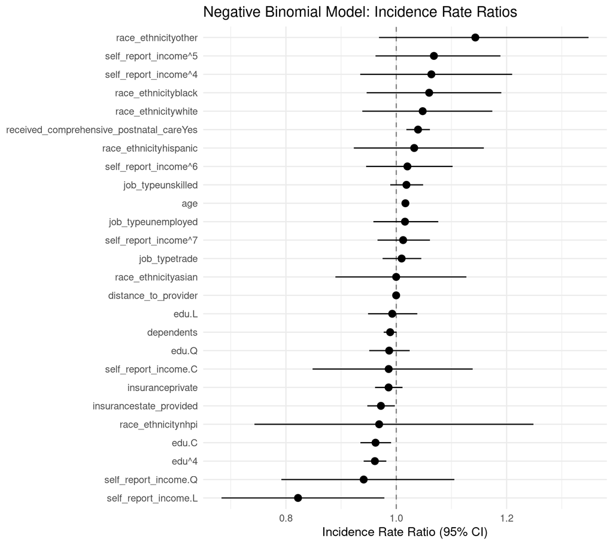

Figure 5: Incidence rate ratios from negative binomial model (exponentiated coefficients with 95% CI)

```r
irr_plot_data <- tidy(fit_nb, conf.int = TRUE, exponentiate = TRUE) |>
  filter(term != "(Intercept)") |>
  mutate(term = reorder(term, estimate))

ggplot(irr_plot_data, aes(x = estimate, y = term)) +
  geom_vline(xintercept = 1, linetype = "dashed", color = "grey50") +
  geom_pointrange(aes(xmin = conf.low, xmax = conf.high)) +
  labs(
    x = "Incidence Rate Ratio (95% CI)",
    y = NULL,
    title = "Negative Binomial Model: Incidence Rate Ratios"
  ) +
  theme_minimal(base_size = 13)
```

### 5. Diagnostics and Responsible Reporting

#### Model Diagnostics

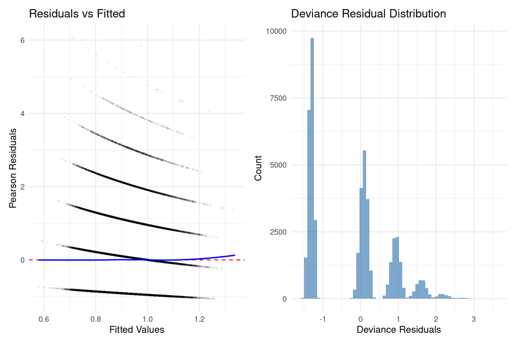

Figure 6: Residual diagnostics for the negative binomial model

```r
diag_df <- tibble(
  fitted = fitted(fit_nb),
  pearson_resid = residuals(fit_nb, type = "pearson"),
  deviance_resid = residuals(fit_nb, type = "deviance")
)

p_resid_fitted <- ggplot(diag_df, aes(x = fitted, y = pearson_resid)) +
  geom_point(alpha = 0.05, size = 0.5) +
  geom_hline(yintercept = 0, color = "red", linetype = "dashed") +
  geom_smooth(method = "loess", se = FALSE, color = "blue", linewidth = 0.8) +
  labs(x = "Fitted Values", y = "Pearson Residuals",
       title = "Residuals vs Fitted") +
  theme_minimal(base_size = 12)

p_resid_hist <- ggplot(diag_df, aes(x = deviance_resid)) +
  geom_histogram(bins = 60, fill = "steelblue", alpha = 0.7) +
  labs(x = "Deviance Residuals", y = "Count",
       title = "Deviance Residual Distribution") +
  theme_minimal(base_size = 12)

p_resid_fitted + p_resid_hist
```

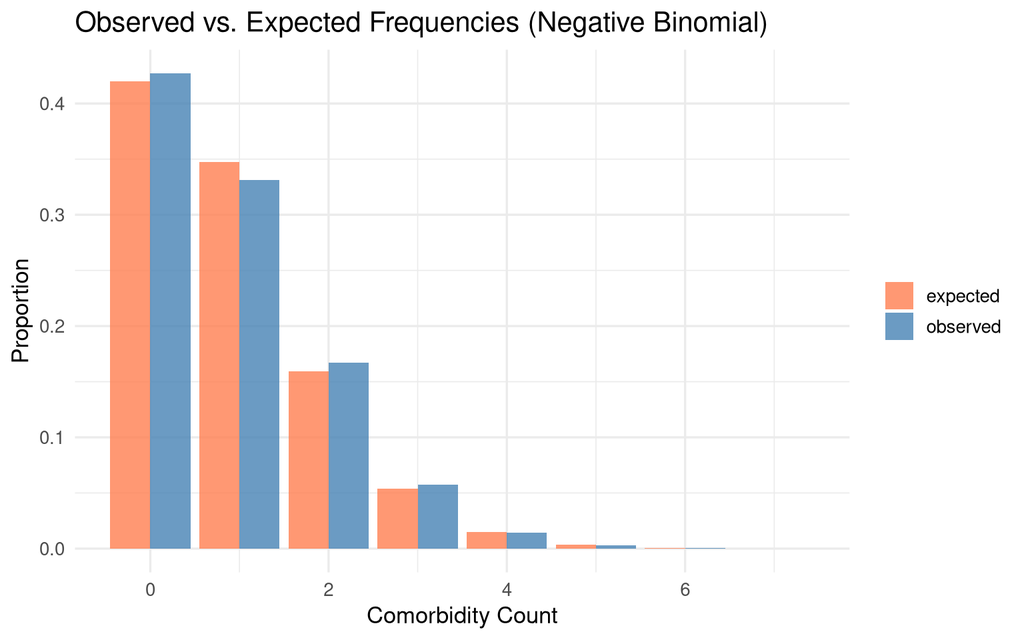

Observed vs expected counts under the negative binomial model

```r
# Compare observed vs predicted count frequencies
obs_freq <- table(df$comorbidity_count)
pred_probs <- sapply(as.integer(names(obs_freq)), function(k) {
  mean(dnbinom(k, mu = fitted(fit_nb), size = fit_nb$theta))
})

rootogram_df <- tibble(
  count = as.integer(names(obs_freq)),
  observed = as.numeric(obs_freq) / nrow(df),
  expected = pred_probs
)

rootogram_df |>
  pivot_longer(cols = c(observed, expected), names_to = "type", values_to = "proportion") |>
  ggplot(aes(x = count, y = proportion, fill = type)) +
  geom_col(position = "dodge", alpha = 0.8) +
  scale_fill_manual(values = c("observed" = "steelblue", "expected" = "coral"),
                    name = NULL) +
  labs(
    x = "Comorbidity Count",
    y = "Proportion",
    title = "Observed vs. Expected Frequencies (Negative Binomial)"
  ) +
  theme_minimal(base_size = 13)
```

#### Assumptions and Limitations

**Model assumptions:**

1. **Conditional independence:** Observations are assumed independent given covariates. However, patients are nested within providers (`provider_id`) and states, introducing potential clustering. A mixed-effects model (e.g., `glmer.nb()`) could account for this, but was not pursued here for parsimony.
2. **Correct mean structure:** We assume the log-linear specification captures the true relationship between covariates and the comorbidity count. No interactions or nonlinear terms for continuous predictors (e.g., age, distance) were included. Residual diagnostics above provide a visual check.
3. **Negative binomial distributional assumption:** The NB model adds a dispersion parameter relative to Poisson. The observed-vs-expected count comparison above assesses goodness-of-fit.

**Limitations:**

- **Cross-sectional, observational data.** All associations should be interpreted as correlations, not causal effects. Unmeasured confounders (e.g., access to prenatal care, health literacy, genetic factors) are likely present.
- **Self-reported income.** Subject to reporting bias and may not reflect actual economic resources (wealth, debt, cost of living).
- **Synthetic data.** This dataset is simulated. Results characterize the data-generating process, not real-world maternal health patterns.
- **No adjustment for multiple comparisons.** With many predictors, some nominally significant results may be spurious.
- **Clustering ignored.** Patients within the same provider or state may share unobserved characteristics. Standard errors may be underestimated.

## Summary of Changes

1. **Loaded and normalized** the 50,000-row dataset. Converted categorical columns (`self_report_income`, `edu`, `race_ethnicity`, `insurance`, `job_type`, `state`, `provider_id`) to factors with explicit levels. Ordered factors were used for income and education. The binary outcome `received_comprehensive_postnatal_care` was converted to a labeled factor.
2. **Summarized** the data: 50,000 rows, 20 columns, zero missing values. Reported descriptive statistics for all numeric and categorical variables. Flagged the right-skewed distance distribution and confirmed all binary indicators were within expected ranges.
3. **Created visualizations** showing postnatal care receipt by insurance status and race/ethnicity, distance-to-provider distributions by care status, and boxplots of distance by insurance and race.
4. **Built `comorbidity_count`** as the sum of 8 binary indicators. Compared Poisson and negative binomial models using AIC and a likelihood ratio test. The negative binomial was selected due to overdispersion. Reported incidence rate ratios with 95% confidence intervals and a coefficient plot.
5. **Reported responsibly** with residual diagnostics, an observed-vs-expected count comparison, and explicit discussion of assumptions (independence, log-linear mean, NB distribution) and limitations (observational design, self-report bias, synthetic data, clustering).